# Advanced issues ALAAM - INSNA XVL

[Johan Koskinen](https://https://www.su.se/english/profiles/kosk-1.615440)

2025-06-22

# Introduction

This tutorial introduces *more advanced* aspects of the Bayesian estimation for auto-logistic actor attribute models (ALAAMs)(Robins, Pattison, and Elliott (2001), Daraganova (2009), and Daraganova and Robins (2013)) developed in Koskinen and Daraganova (2022).

The workshop will go through

1. Data missing at random
2. Data missing not at random
3. More contagion effects
4. Interacting contagion with other effects
5. Specifying “informative” prior distributions

## Preamble for ALAAM

Load the main functions of `balaam` from GitHub and load network packages.

```r
source("https://raw.githubusercontent.com/johankoskinen/ALAAM/main/balaam.R")
require(sna)
require(network)
```

and don’t forget to consult the (proto-) manual which is avaialble on GitHub [alaam_effects](https://github.com/johankoskinen/ALAAM/blob/main/alaam_effects.pdf).

## Load and format data

The s50 dataset

```r
temp <- tempfile()
download.file("https://www.stats.ox.ac.uk/~snijders/siena/s50_data.zip",temp)
adj <- as.matrix( read.table(unz(temp, "s50-network1.dat")) )
sport <- read.table(unz(temp, "s50-sport.dat"))
smoke <- read.table(unz(temp, "s50-smoke.dat"))
alcohol <- read.table(unz(temp, "s50-alcohol.dat"))
unlink(temp)
```

format

```r
n <- nrow(adj)
adj <- as.matrix(adj) # convert from data.frame to matrix
smoke <- smoke[,2] # use wave 2
smoke[smoke<2] <- 0 # set non-smoker to 0
smoke[smoke>0] <- 1 # set occasional and regular to 1
sport <- sport-1
my.data <- data.frame(smoke=smoke, alcohol=alcohol[,1],sport=sport[,1])
```

# Model selection

GOF only checks if there are features of data that are not adequately captured by the model. We cannot say **how much** better or worse the GOF for one model is compared to another - either the model fits or it does not (and we do not want to overfit).

To compare models we may quantify the fit of a model, drawing by analogy with standard generalised linear models.

## Estimated models

Estimate a network activity model

```r
res.0 <- estimate.alaam(smoke ~odegree+alcohol+sport, my.data, adjacency=adj,
                           Iterations=1000)
```

```
## Network is directed with  50 nodes
```

```
## [1] "you have p:  5"
##
## observed stats:  17 25 43 59 11
## number of covariates:  3
## A thinning of  1 ,
## (parameter) burn-in of  1 , and
## iterations of  1000 ,
## yields a sample size of  1000 .
## Estimation using pseudo likelihood:
##
## (Printing every  100  iterations)
##
## you have done  100  iterations out of  1000
## theta: -3.003 0 0.266 0.911 -0.309
## you have done  200  iterations out of  1000
## theta: -5.276 0 0.132 1.314 0.498
## you have done  300  iterations out of  1000
## theta: -5.227 0 0.34 1.329 -0.383
## you have done  400  iterations out of  1000
## theta: -1.604 0 0.118 0.7 -1.707
## you have done  500  iterations out of  1000
## theta: -4.491 0 0.07 1.363 -0.977
## you have done  600  iterations out of  1000
## theta: -1.774 0 0.436 0.546 -1.549
## you have done  700  iterations out of  1000
## theta: -4.864 0 0.594 1.311 -2.235
## you have done  800  iterations out of  1000
## theta: -2.629 0 0.071 1.259 -2.147
## you have done  900  iterations out of  1000
## theta: -3.104 0 0.381 1.123 -1.73
## you have done  1000  iterations out of  1000
## theta: -2.446 0 0.054 0.608 -0.446
## summaries of the posterior draws:
##              mean      sd     ESS SACF 10 SACF 30
## intercept -3.2582  1.3527 41.2078  0.4813 -0.0386
## contagion  0.0000  0.0000  0.0000
## odegree    0.2219  0.3142 45.4385  0.4413  0.0824
## alcohol    0.9136  0.3602 42.8673  0.3993  0.0855
## sport     -1.0590  0.7353 39.6544  0.4411  0.0826
##
## if ESS is small you need to increase the number of Iterations
## if and/or increase the parameter thinning which is currently  1 .
## Alternatively, adjust the proposals by improving the proposal variance-covariance:
## e.g. set PropSigma equal to the covariance of the posterior draws, or
## increase/decrease the scaling of the proposals (default: scaling=1/sqrt( 5 ); current:  1 /sqrt( 5 )
## Acceptance ratio:  0.428  (idealy around 0.25)
```

then estimate a simple contagion model

```r
res.DC.0 <- estimate.alaam(smoke ~idegree+odegree+alcohol+sport+simple, my.data, adjacency=adj,
                           Iterations=1000)
```

```
## Network is directed with  50 nodes
## [1] "you have p:  6"
##
## observed stats:  17 25 40 43 59 11
## number of covariates:  4
## A thinning of  1 ,
## (parameter) burn-in of  1 , and
## iterations of  1000 ,
## yields a sample size of  1000 .
##
## you have done  100  iterations out of  1000
## theta: -1.962 0.62 -0.46 0.203 0.58 -1.334
## you have done  200  iterations out of  1000
## theta: -3.23 0.565 -0.578 0.325 0.993 -1.082
## you have done  300  iterations out of  1000
## theta: -2.94 0.741 -0.796 0.564 0.438 -0.255
## you have done  400  iterations out of  1000
## theta: -1.115 0.618 -0.532 -0.07 0.317 -0.006
## you have done  500  iterations out of  1000
## theta: -3.874 0.733 -1.005 0.319 1.08 -0.147
## you have done  600  iterations out of  1000
## theta: -1.697 1.031 -0.953 0.18 0.383 -0.231
## you have done  700  iterations out of  1000
## theta: -1.711 0.198 -0.255 0.361 0.608 -1.8
## you have done  800  iterations out of  1000
## theta: -3.895 0.69 -0.431 0.408 0.782 -0.623
## you have done  900  iterations out of  1000
## theta: -2.774 0.476 -0.909 0.654 1.134 -1.64
## you have done  1000  iterations out of  1000
## theta: -3.024 0.636 -0.597 0.524 0.952 -1.741
## summaries of the posterior draws:
##              mean      sd     ESS SACF 10 SACF 30
## intercept -2.7344  1.2132 29.4701  0.6033  0.1073
## contagion  0.5856  0.2745 25.4904  0.5647  0.1723
## idegree   -0.7075  0.3109 23.4608  0.6136  0.1340
## odegree    0.3457  0.2793 31.5234  0.5274  0.0890
## alcohol    0.8250  0.3256 42.4814  0.4616  0.0425
## sport     -0.9516  0.7823 22.6800  0.6107  0.2267
##
## if ESS is small you need to increase the number of Iterations
## if and/or increase the parameter thinning which is currently  1 .
## Alternatively, adjust the proposals by improving the proposal variance-covariance:
## e.g. set PropSigma equal to the covariance of the posterior draws, or
## increase/decrease the scaling of the proposals (default: scaling=1/sqrt( 6 ); current:  1 /sqrt( 6 )
## Acceptance ratio:  0.267  (idealy around 0.25)
```

```r
res.DC.1 <- estimate.alaam(smoke ~idegree+odegree+alcohol+sport+simple, my.data, adjacency=adj,
                           Iterations=5100,
                        prevBayes=res.DC.0,# our first estimation
                        par.burnin=100,# discard the first 100 iterations
                        thinning=10)# only use every
```

```
## [1] "you have p:  6"
##
## observed stats:  17 25 40 43 59 11
## number of covariates:  4
## A thinning of  10 ,
## (parameter) burn-in of  100 , and
## iterations of  5100 ,
## yields a sample size of  501 .
##
## you have done  510  iterations out of  5100
## theta: -7.762 0.499 -1.11 1.529 1.584 -0.955
## you have done  1020  iterations out of  5100
## theta: -5.055 0.711 -1.253 1.589 1.006 -1.638
## you have done  1530  iterations out of  5100
## theta: 0.017 0.466 -0.285 -0.067 0.218 -1.723
## you have done  2040  iterations out of  5100
## theta: -3.443 0.656 0.036 -0.3 1.037 -1.187
## you have done  2550  iterations out of  5100
## theta: -4.561 0.504 -0.689 0.565 1.264 -0.854
## you have done  3060  iterations out of  5100
## theta: -4.433 0.922 -1.187 1.181 0.982 -1.612
## you have done  3570  iterations out of  5100
## theta: -2.414 0.713 -0.56 0.523 0.503 -1.776
## you have done  4080  iterations out of  5100
## theta: -1.424 0.859 -0.557 -0.35 0.855 -1.343
## you have done  4590  iterations out of  5100
## theta: -2.816 0.538 -0.401 0.356 0.482 -0.515
## you have done  5100  iterations out of  5100
## theta: -4.891 0.081 -0.689 0.635 1.566 -0.923
## summaries of the posterior draws:
##               mean       sd      ESS  SACF 10 SACF 30
## intercept  -3.8644   1.6092  75.5272   0.1923
## contagion   0.6296   0.3052  79.1526   0.0440
## idegree    -0.7775   0.3850  59.0717   0.1140
## odegree     0.4805   0.4215  70.9510   0.0087
## alcohol     1.0756   0.4164 102.4779   0.0277
## sport      -0.9875   0.8448  76.0083   0.1263
##
## if ESS is small you need to increase the number of Iterations
## if and/or increase the parameter thinning which is currently  10 .
## Alternatively, adjust the proposals by improving the proposal variance-covariance:
## e.g. set PropSigma equal to the covariance of the posterior draws, or
## increase/decrease the scaling of the proposals (default: scaling=1/sqrt( 6 ); current:  1 /sqrt( 6 )
## Acceptance ratio:  0.4835294  (idealy around 0.25)
```

```r
res.DC.2 <- estimate.alaam(smoke ~idegree+odegree+alcohol+sport+simple, my.data, adjacency=adj,
                           Iterations=5100,
                           prevBayes=res.DC.0,# our first estimation
                           par.burnin=100,# discard the first 100 iterations
                           thinning=10,# only use every 10
                           recalibrate=TRUE,# use proposal variance from previous posterior
                           scaling = 0.55)# scale down
```

```
## [1] "you have p:  6"
##
## observed stats:  17 25 40 43 59 11
## number of covariates:  4
## A thinning of  10 ,
## (parameter) burn-in of  100 , and
## iterations of  5100 ,
## yields a sample size of  501 .
##
## you have done  510  iterations out of  5100
## theta: -4.872 0.409 -0.908 0.759 1.212 -0.635
## you have done  1020  iterations out of  5100
## theta: -2.992 0.671 -0.732 0.179 1.064 -0.869
## you have done  1530  iterations out of  5100
## theta: -2.298 0.844 -0.505 -0.019 0.667 -0.951
## you have done  2040  iterations out of  5100
## theta: -4.007 0.951 -1.139 0.876 0.99 -1.275
## you have done  2550  iterations out of  5100
## theta: -4.966 0.292 -0.445 0.844 0.889 -0.043
## you have done  3060  iterations out of  5100
## theta: -5.404 0.729 -0.483 0.044 1.466 -0.021
## you have done  3570  iterations out of  5100
## theta: -2.051 0.586 -0.521 -0.269 0.838 -0.959
## you have done  4080  iterations out of  5100
## theta: -5.347 0.864 -0.331 0.017 1.362 -1.134
## you have done  4590  iterations out of  5100
## theta: -4.138 1.166 -1.775 0.968 1.34 -1.577
## you have done  5100  iterations out of  5100
## theta: -2.925 1.019 -0.738 -0.003 0.948 -1.187
## summaries of the posterior draws:
##               mean       sd      ESS  SACF 10 SACF 30
## intercept  -3.5252   1.5383  58.4647   0.1459
## contagion   0.6160   0.3016 109.6305   0.0345
## idegree    -0.8093   0.4390  44.3310   0.2663
## odegree     0.4215   0.4519  40.0185   0.0909
## alcohol     1.1102   0.3992  58.3812   0.1358
## sport      -1.1388   0.8539  64.8527  -0.0745
##
## if ESS is small you need to increase the number of Iterations
## if and/or increase the parameter thinning which is currently  10 .
## Alternatively, adjust the proposals by improving the proposal variance-covariance:
## e.g. set PropSigma equal to the covariance of the posterior draws, or
## increase/decrease the scaling of the proposals (default: scaling=1/sqrt( 6 ); current:  0.55 /sqrt( 6 )
## Acceptance ratio:  0.07235294  (idealy around 0.25)
```

## Posterior deviance

Aitkin, Vu, and Francis (2017) proposed that a graphical comparison of models can be done through comparing the posterior distribution of the deviance. The deviance is here defined as minus twice the log likelihood
$$D(\boldsymbol{\theta})=-2 \log[p_{\boldsymbol{\theta}}(\boldsymbol{y} |
\mathbf{X} )].$$
Calculate the deviance $D(\boldsymbol{\theta}_t)$ for the parameters in your posterior.

> Models with smaller deviance are prefered to models with large deviance

### Independent model

The deviances can be calculated exactly for the independent model

```r
ind.post.dev <- post.deviance.alaam(res.0)
```

### Contagion model

For the model with contagion, numerical methods are required (see `alaam_effects.pdf`). The arguments are here deliberately set too low to speed up the calculateions.

When evaluating deviance across the posterior draws, we ideally want to have suffiently spaced out and approximately independent draws from the posterior os possible. In the list of arguments `burnin` is the number of parameter draws that are discarded and `thinning` is the number of iterations that are discarded between sample draws. Node that if `dim(res.1$Thetas)[1]` is $N$, then the total number of parameter draws you use will be `(N-burnin)/thinning`.

Calculating the posterior deviances is done based on path of length `numbridges`, linking `thetaRef` with the paramter. The (log) ration of normalising constants is estimated based on a MCMC sample from the model based on `numYsamps`. This sample size has to be large but does not have to be too large. The thining in generating these vectors is `Yburnin`. The larger this and numYsamps` the better precision you get.

> Evaluating the deviance takes a while - be patient; the routine will print to screen how many paramters you have eveluated the relative deviance for out of the total number

```r
my.dev.post <- post.deviance.alaam(res.DC.2,# the estimation object
                                  numBridges=5,# the safer default is 20
                                  thinning.like = 1000,# thinning in drawing y; should be higher
                                  sample.size = 20,# number of y drawn for each bridge
                                  cov.sample.burnin = NULL,
                                  printFreq=10,# print to screen after done 10
                                  mult.fact = 30,# depreciated
                                  num.outs=100)# number of devaiance evaluations to return
```

```
##
## Likelihood evaluated for draw  10  (out of  100 )
## Likelihood evaluated for draw  20  (out of  100 )
## Likelihood evaluated for draw  30  (out of  100 )
## Likelihood evaluated for draw  40  (out of  100 )
## Likelihood evaluated for draw  50  (out of  100 )
## Likelihood evaluated for draw  60  (out of  100 )
## Likelihood evaluated for draw  70  (out of  100 )
## Likelihood evaluated for draw  80  (out of  100 )
## Likelihood evaluated for draw  90  (out of  100 )
## Likelihood evaluated for draw  100  (out of  100 )
```

### Visualising deviance

Aitkin, Vu, and Francis (2017) recomnded comparing the distributions in terms of their cumulative distribution functions
$$\Pr(D(\boldsymbol{\theta})<d )$$

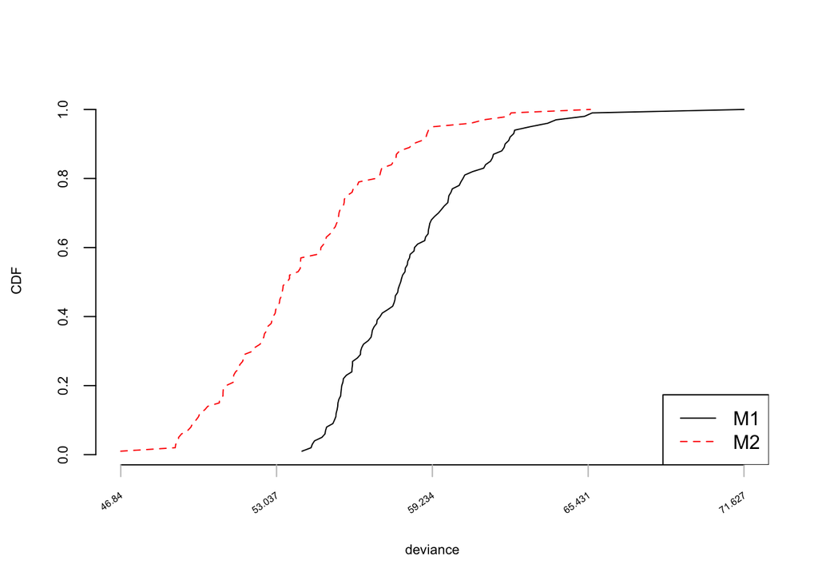

```r
plot.deviance.alaam(dev.1=ind.post.dev, dev.2=my.dev.post)
```

> There is separatation between the CDFs

## DIC

The DIC can be calculated from the posterior deviances using the formula of Spiegelhalter et al. (2002) or Gelman et al. (2013). The difference between the two ways of calculating DIC lies in the calculation of $p_D$. Here we use

$$DIC= E[D(\boldsymbol{\theta})]+V(D(\boldsymbol{\theta}))/2$$
Calculate the DIC for the two models using `alaam.dic`

```r
c( alaam.dic(ind.post.dev),alaam.dic(my.dev.post) )
```

```
## [1] 62.72678 59.88669
```

> What model is the winner? Smaller is better

# MAR data

```r
is.miss <- sample(c(1:50), size=5, replace = FALSE)
true.vals <- my.data$smoke[is.miss]
my.data$smoke[is.miss] <- NA
table(my.data$smoke, useNA='always')
```

```
##
##    0    1 <NA>
##   29   16    5
```

Assuming that data are missing at random (MAR),

```r
res.MAR.0 <- estimate.alaam(smoke ~odegree+alcohol+sport+simple,
                            my.data, adjacency=adj,
                           Iterations=1000,
                           missFreq = 500)
```

```
## Network is directed with  50 nodes
## [1] "you have  5  missing entries in response"
## NULL
## [1] "you have p:  5"
##
## observed stats:  16 22 41 55 11
## number of covariates:  3
## A thinning of  1 ,
## (parameter) burn-in of  1 , and
## iterations of  1000 ,
## yields a sample size of  1000 .
##
## you have done  100  iterations out of  1000
## theta: -2.375 0.943 -0.509 0.35 -0.49
## observed stats:  18 27 44 63 12
##
## imputed ones:  2  out of  5
##
## you have done  200  iterations out of  1000
## theta: -2.161 0.509 -0.007 0.12 0.179
## observed stats:  17 24 42 59 12
##
## imputed ones:  1  out of  5
##
## you have done  300  iterations out of  1000
## theta: -2.404 0.71 -0.055 0.509 -1.026
## observed stats:  16 22 41 55 11
##
## imputed ones:  0  out of  5
##
## you have done  400  iterations out of  1000
## theta: -6.396 0.664 0.184 0.917 1.229
## observed stats:  17 24 43 58 12
##
## imputed ones:  1  out of  5
##
## you have done  500  iterations out of  1000
## theta: -1.415 0.224 0.223 0.161 -1.104
## observed stats:  17 22 43 57 12
##
```

[output cut: 31 more lines]

```
##
## summaries of the posterior draws:
##              mean      sd     ESS SACF 10 SACF 30
## intercept -3.2242  1.4871 20.4921  0.6007  0.2634
## contagion  0.4315  0.2669 32.5304  0.4995  0.0924
## odegree   -0.0233  0.2808 43.8065  0.4280  0.0052
## alcohol    0.6572  0.3810 22.3117  0.5950  0.3466
## sport     -0.4534  0.8118 23.9399  0.6330  0.1743
##
## if ESS is small you need to increase the number of Iterations
## if and/or increase the parameter thinning which is currently  1 .
## Alternatively, adjust the proposals by improving the proposal variance-covariance:
## e.g. set PropSigma equal to the covariance of the posterior draws, or
## increase/decrease the scaling of the proposals (default: scaling=1/sqrt( 5 ); current:  1 /sqrt( 5 )
## Acceptance ratio:  0.319  (idealy around 0.25)
```

The output to screen that says for example imputed ones: 2 out of 5, tells us how many of the 5 missing values in that iteration that have been imputed with a 1.

> With 10% or responses missing we see some attenuation of effects (standard deviations increase)

### Check imputations

The imputed values are stored in `res.MAR.0$imputed.obs`, and here we can compare the imputed values with the true values

```r
table(rowMeans(res.MAR.0$imputed.obs[is.miss,]),true.vals)
```

```
##        true.vals
##         0 1
##   0.104 1 0
##   0.108 1 0
##   0.31  1 0
##   0.4   1 0
##   0.662 0 1
```

## GOF with missing

In the ordinary GOF the observed statistics are compared with the simulated statistics. When we have missing data, we do not have one value for each statistic, but a range of values.

```r
sim.2.na <- get.gof.distribution(NumIterations=500, # number of vectors to draw
                                  res=res.MAR.0, # the ALAAM estimation object that contains model and results
                                  burnin=100, # no. iterations discarded from GOF distribution
                                  thinning = 1000, # no. iterations between sample points
                                  contagion ='simple') #
```

```
## Simulating GOF took  3.45696
## Calculating statistics took  0.238174
```

When calculating the statistics, we need to add the argument `Imp.gof`

```r
gof.table(obs.stats=    sim.2.na$stats, # observed statistics included  not fitted statistics
          sim.stats=    sim.2.na$Sav.gof, # simulated goodness-of-fit statistics
          name.vec= sim.2.na$gof.stats.names, # names of statistics calculate, not all will be used if undirected
          tabname='ALAAMGofalt', # name of file saved
          pvalues=TRUE, # posterior predictive p-values
          save.tab ='csv', # save a csv file or a LaTex file
          Imp.gof = sim.2.na$Imp.gof)
```

```
##                     obs   mean  p-val
## intercept        17.584 16.634  0.179
## simple cont.     25.454 18.870  0.111
## recip cont.       7.396  6.594  0.169
## indirect cont.   59.504 33.510  0.045
## closedind cont.  20.648 16.474  0.143
## transitive cont. 12.324 10.040  0.183
## outdegree        43.664 38.860  0.154
## indegree         40.528 42.538  0.209
## reciprochation   26.556 27.658  0.205
## instar           56.916 59.624  0.199
## outstar          44.080 35.960  0.123
## twopath          87.996 86.908  0.243
## in3star          70.972 64.854  0.303
## out3star         22.000 16.280  0.120
## transitive       33.324 30.310  0.164
## cyclic           17.634 23.010  0.102
## indirect         94.072 73.516  0.081
## excl.indirect    54.438 39.310  0.057
```

### Plot goodness of fit with missing

We can compare the statistics for the predictive distribution under the fitted model, with the imputed or complemented datasets. Look at the statistic for ‘indirect contagion’

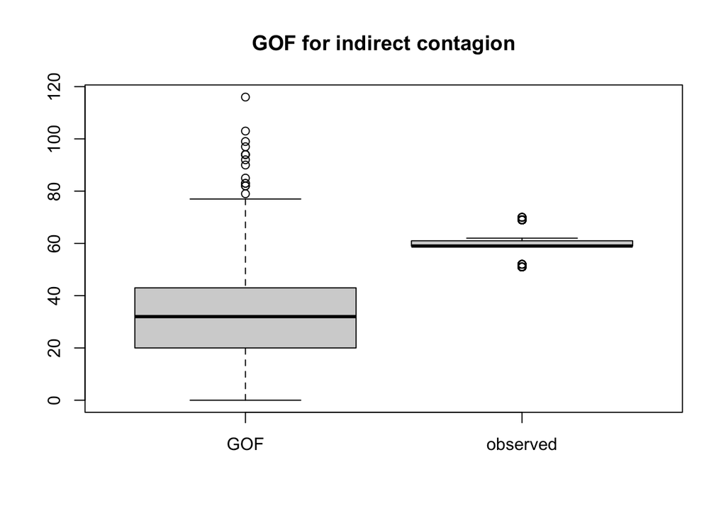

```r
boxplot(sim.2.na$Sav.gof[4,],sim.2.na$Imp.gof[4,],names = c('GOF','observed'), main='GOF for indirect contagion')
```

### Posterior deviance

With missing data, the likelihood is marginalised with respect to the missing entries when calculating the posterior deviance.

```r
# Bug prevents this from runnig
my.dev.post.MAR <- post.deviance.alaam(res.MAR.0,# the estimation object
                                  numBridges=5,# the safer default is 20
                                  thinning.like = 1000,# thinning in drawing y; should be higher
                                  sample.size = 20,# number of y drawn for each bridge
                                  cov.sample.burnin = NULL,
                                  printFreq=10,# print to screen after done 10
                                  mult.fact = 30,# depreciated
                                  num.outs=100)# number of devaiance evaluations to return
```

# MNAR data

We can never infer whether data are MAR or MNAR. We can, however, estimate them model under different assumptions for a MNAR process. In `balaam`, we can specify a bias in the missingness mechanism. Letting $D_i$ be an indicator whether the variable $Y_i$ is missing or not, then, independently for each node $i=1,\ldots,n$, the model

$${\rm{logit}}[\Pr(D_{ij}=1 \mid \boldsymbol{y})]=\alpha+\gamma y_i$$

```r
res.MNAR.0 <- estimate.alaam(smoke ~idegree+odegree+alcohol+sport+simple,
                            my.data, adjacency=adj,
                           Iterations=1000,
                           missFreq = 500,
                           missingPhi =0.5)
```

```
## Network is directed with  50 nodes
## [1] "you have  5  missing entries in response"
## NULL
## [1] "you have p:  6"
##
## observed stats:  16 22 37 41 55 11
## number of covariates:  4[1] "MNAR mechanism specified based on response and    covariates"
##
## A thinning of  1 ,
## (parameter) burn-in of  1 , and
## iterations of  1000 ,
## yields a sample size of  1000 .
##
## you have done  100  iterations out of  1000
## theta: -2.8 0.767 -0.905 0.3 0.704 -0.224
## observed stats:  17 24 38 42 59 12
##
## imputed ones:  1  out of  5
##
## you have done  200  iterations out of  1000
## theta: -3.684 0.421 0.014 -0.003 1.009 -0.875
## observed stats:  17 25 40 43 59 11
##
## imputed ones:  1  out of  5
##
## you have done  300  iterations out of  1000
## theta: -5.473 0.454 -0.126 0.126 1.088 0.35
## observed stats:  19 27 42 46 65 13
##
## imputed ones:  3  out of  5
##
## you have done  400  iterations out of  1000
## theta: -3.024 0.588 -0.34 0.369 0.69 -0.688
## observed stats:  20 29 45 48 68 14
##
## imputed ones:  4  out of  5
##
## you have done  500  iterations out of  1000
## theta: -1.687 0.48 -0.43 0.128 0.704 -1.338
## observed stats:  18 27 41 44 63 12
```

[output cut: 33 more lines]

```
## summaries of the posterior draws:
##              mean      sd     ESS SACF 10 SACF 30
## intercept -3.1728  1.6904 19.8117  0.6419  0.1076
## contagion  0.6854  0.3023 28.1181  0.5686  0.0565
## idegree   -0.6857  0.3921 16.5041  0.7407  0.3846
## odegree    0.1792  0.3649 27.2912  0.5994  0.2356
## alcohol    1.0351  0.3787 34.6224  0.4855 -0.0607
## sport     -0.9509  0.9347 14.6310  0.7641  0.4053
##
## if ESS is small you need to increase the number of Iterations
## if and/or increase the parameter thinning which is currently  1 .
## Alternatively, adjust the proposals by improving the proposal variance-covariance:
## e.g. set PropSigma equal to the covariance of the posterior draws, or
## increase/decrease the scaling of the proposals (default: scaling=1/sqrt( 6 ); current:  1 /sqrt( 6 )
## Acceptance ratio:  0.275  (idealy around 0.25)
```

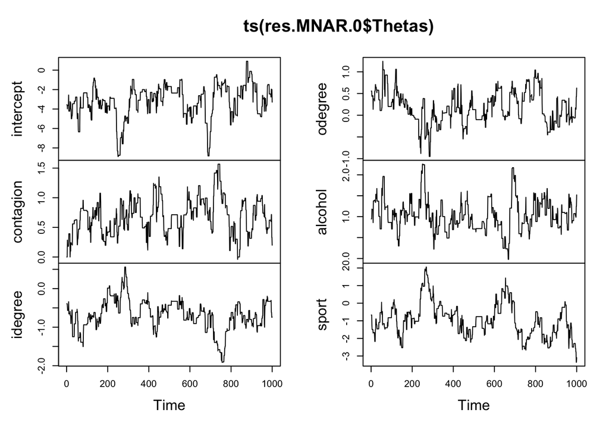

```r
plot(ts(res.MNAR.0$Thetas))
```

### Sensitivity analysis

If perform the analysis for a range of different values of $\gamma$, you would compare the posteriors under different MNAR assumptions. Of particular interest is to ascertain how strong the bias has to be for your conclusions to be qualitatively different compare to MAR.

# More contagion

## Reciprocal contagion

Reinstate the missing values

```r
my.data$smoke[is.miss] <- true.vals
table(my.data$smoke, useNA='always')
```

```
##
##    0    1 <NA>
##   33   17    0
```

Given that we have directed network data, we may want to investigate if there is stronger or weaker contagion across reciprocated ties.

> For non-direct congation effects, the lower order contagion as well as any other lower-oder statistics need to be included.

Consequently we define the model

```r
res.DC.RC.1 <- estimate.alaam(smoke ~ odegree+alcohol+sport+simple
                              +recipties
                              +recip,
                              my.data, adjacency=adj,
                           Iterations=5100,
                        par.burnin=100,# discard the first 100 iterations
                        thinning=10)# only use every
```

```
## Network is directed with  50 nodes
## [1] "you have p:  7"
##
## observed stats:  17 25 7 43 59 11 26
## number of covariates:  4
## A thinning of  10 ,
## (parameter) burn-in of  100 , and
## iterations of  5100 ,
## yields a sample size of  501 .
##
## you have done  510  iterations out of  5100
## theta: -2.335 0.826 -0.328 -0.268 0.204 0.314 -0.121
## you have done  1020  iterations out of  5100
## theta: -3.624 0.842 -1.313 0.598 0.901 -1.32 -0.634
## you have done  1530  iterations out of  5100
## theta: -3.141 1.275 -0.91 0.066 0.778 -0.697 -0.983
## you have done  2040  iterations out of  5100
## theta: -3.685 0.951 -2.067 0.232 1.099 -1.641 -0.226
## you have done  2550  iterations out of  5100
## theta: -3.346 0.654 -0.476 -0.455 1.167 -0.902 -0.535
## you have done  3060  iterations out of  5100
## theta: -4.793 1.166 -0.476 0.329 1.14 -0.504 -1.324
## you have done  3570  iterations out of  5100
## theta: -4.236 0.184 0.764 0.409 1.622 -0.345 -1.821
## you have done  4080  iterations out of  5100
## theta: -3.447 -0.087 -0.198 0.565 1.401 -2.489 -0.121
## you have done  4590  iterations out of  5100
## theta: -0.623 1.598 -1.782 -0.08 0.217 -1.069 -1.355
## you have done  5100  iterations out of  5100
## theta: -3.663 0.742 -1.031 0.336 1.306 -1.482 -0.869
## summaries of the posterior draws:
##                mean       sd      ESS  SACF 10 SACF 30
## intercept   -3.2389   1.4968  72.7505   0.0431
## contagion    0.6002   0.5150 116.5606   0.0664
## recip cont  -0.3813   1.3424  90.1000   0.0353
## odegree      0.3358   0.5015  97.3897  -0.0158
## alcohol      0.9502   0.4089  95.3246   0.0142
## sport       -0.7381   0.7982 112.1464   0.0770
## recipties   -1.0244   0.7612  72.0795   0.0978
##
## if ESS is small you need to increase the number of Iterations
## if and/or increase the parameter thinning which is currently  10 .
## Alternatively, adjust the proposals by improving the proposal variance-covariance:
## e.g. set PropSigma equal to the covariance of the posterior draws, or
## increase/decrease the scaling of the proposals (default: scaling=1/sqrt( 7 ); current:  1 /sqrt( 7 )
## Acceptance ratio:  0.2737255  (idealy around 0.25)
```

```r
res.DC.IC.1 <- estimate.alaam(smoke ~ odegree+alcohol+sport+simple
                              +indirect
                              +indirties,
                              my.data, adjacency=adj,
                           Iterations=1000,
                        par.burnin=100,# discard the first 100 iterations
                        thinning=5)# only use every
```

```
## Network is directed with  50 nodes
## [1] "you have p:  7"
##
## observed stats:  17 25 59 43 59 11 53
## number of covariates:  4
## A thinning of  5 ,
## (parameter) burn-in of  100 , and
## iterations of  1000 ,
## yields a sample size of  181 .
##
## you have done  100  iterations out of  1000
## theta: -5.794 -0.611 0.525 -0.156 1.238 -0.362 0.219
## you have done  200  iterations out of  1000
## theta: -3.667 -0.011 0.202 -0.493 0.811 -0.815 0.402
## you have done  300  iterations out of  1000
## theta: -3.306 0.129 0.345 -0.621 0.734 -0.231 0.091
## you have done  400  iterations out of  1000
## theta: -3.951 -0.869 0.701 -0.14 1.003 -1.066 -0.077
## you have done  500  iterations out of  1000
## theta: -4.283 0.296 0.16 -0.107 1.009 -0.797 0.09
## you have done  600  iterations out of  1000
## theta: -4.006 -0.181 0.256 0.365 1.081 -1.784 -0.069
## you have done  700  iterations out of  1000
## theta: -4.061 -0.192 0.373 0.385 0.706 -0.95 -0.088
## you have done  800  iterations out of  1000
## theta: -4.825 -1.312 0.887 -1.495 1.731 0.031 0.161
## you have done  900  iterations out of  1000
## theta: -4.94 0.142 0.128 -0.2 1.327 -1.111 0.221
## you have done  1000  iterations out of  1000
## theta: -7.706 -1.237 0.787 -0.263 1.806 -0.455 0.429
## summaries of the posterior draws:
##                   mean       sd      ESS  SACF 10 SACF 30
## intercept      -4.1361   1.5384  17.3194   0.1906
## contagion      -0.2603   0.4058  47.5683  -0.1960
## indirect cont   0.3939   0.1991 115.5537  -0.3079
## odegree        -0.3018   0.4917  14.1722   0.1686
## alcohol         1.0231   0.4245  10.7168   0.4013
## sport          -1.1015   0.7284  27.8378  -0.1826
## indirties       0.1576   0.2349  24.8948  -0.0244
##
## if ESS is small you need to increase the number of Iterations
## if and/or increase the parameter thinning which is currently  5 .
## Alternatively, adjust the proposals by improving the proposal variance-covariance:
## e.g. set PropSigma equal to the covariance of the posterior draws, or
## increase/decrease the scaling of the proposals (default: scaling=1/sqrt( 7 ); current:  1 /sqrt( 7 )
## Acceptance ratio:  0.275  (idealy around 0.25)
```

> How are parameters for contagion, reciprochal contagion and reciprocal ties related?

# Interacting contagion

Assume that we hypothesis that social influence on smoking is stronger for heavy drinkers than others. We can test this hypothesis by interacting contagion with alcohol

```r
res.DC.ADC.1 <- estimate.alaam(smoke ~ odegree+alcohol+sport+simple+alcohol*simple,
                              my.data, adjacency=adj,
                           Iterations=5100,
                        par.burnin=100,# discard the first 100 iterations
                        thinning=10)# only use every
```

```
## Network is directed with  50 nodes
## [1] "you have p:  6"
##
## observed stats:  17 25 43 59 11 99
## number of covariates:  3
## A thinning of  10 ,
## (parameter) burn-in of  100 , and
## iterations of  5100 ,
## yields a sample size of  501 .
##
## you have done  510  iterations out of  5100
## theta: -3.982 0.283 0.143 1.256 -1.698 -0.045
## you have done  1020  iterations out of  5100
## theta: -0.988 0.503 -0.582 0.453 -2.052 0.089
## you have done  1530  iterations out of  5100
## theta: -3.009 1.093 -1.013 0.693 1.058 -0.048
## you have done  2040  iterations out of  5100
## theta: -2.265 0.177 0.427 0.304 -0.848 0.016
## you have done  2550  iterations out of  5100
## theta: -0.948 0.585 -0.252 0.425 -2.086 0
## you have done  3060  iterations out of  5100
## theta: -2.875 0.368 -0.494 1.17 -1.689 0.036
## you have done  3570  iterations out of  5100
## theta: -3.296 -0.097 -0.271 1.349 -1.92 0.067
## you have done  4080  iterations out of  5100
## theta: -2.446 0.855 -0.096 0.66 -1.559 -0.078
## you have done  4590  iterations out of  5100
## theta: -4.869 -0.228 0.782 1.04 -1.441 0.043
## you have done  5100  iterations out of  5100
## theta: -1.185 0.467 -0.516 0.542 -0.81 0.022
## summaries of the posterior draws:
##                               mean       sd      ESS  SACF 10 SACF 30
## intercept                  -3.3319   1.5924  93.0258   0.0142
## contagion                   0.3414   0.3262 126.1987   0.0270
## odegree                     0.0649   0.3625 108.1776   0.0311
## alcohol                     0.7678   0.4202 101.8101  -0.0243
## sport                      -0.8657   0.7439 112.4020  -0.0243
## interaction  2 :  alcohol   0.0137   0.0651  59.1356   0.1051
##
## if ESS is small you need to increase the number of Iterations
## if and/or increase the parameter thinning which is currently  10 .
## Alternatively, adjust the proposals by improving the proposal variance-covariance:
## e.g. set PropSigma equal to the covariance of the posterior draws, or
## increase/decrease the scaling of the proposals (default: scaling=1/sqrt( 6 ); current:  1 /sqrt( 6 )
## Acceptance ratio:  0.3198039  (idealy around 0.25)
```

# Informative priors

The inference pressuposes a prior (subjective) prior distribution $\pi(\textbf{\theta})$ for parameters. The default in `estimate.alaam` is to set this prior constant (and therefore improper). There are cases where you need a proper prior distribution. For example, if you want to calculate so-called Bayes-factors. For some data and model combinations, nuisance parameters might need to be included but not desired to be estimated.

There are two types of standard prior distributions.

## Shrinkage prior

A convenient prior is
$$\boldsymbol{\theta} \thicksim \mathcal{N}_p(\boldsymbol{\mu},\lambda
I^{-1})$$
where $\boldsymbol{\mu}$ is all zero, except $\mu_1$ which is set to the MLE for the intercept. For variance, $\lambda>0$ is a chosen shrinkage and $I$ is an approximation to the information matrix.

The argument to `estimate.alaam` is `scalePrior`. Calling this $c$, the prior variance-covariance is set to
$$c\left\{\mathbb{E}_{\boldsymbol{\mu}}[\boldsymbol{z}(\boldsymbol{y})\boldsymbol{z}(\boldsymbol{y})^{\top}]-\mathbb{E}_{\boldsymbol{\mu}}[\boldsymbol{z}(\boldsymbol{y})]\mathbb{E}_{\boldsymbol{\mu}}[\boldsymbol{z}(\boldsymbol{y})]^{\top}\right\}^{-1}$$
## Subjective prior

A subjectively determined normal prior

$$\boldsymbol{\theta} \thicksim
\mathcal{N}_p(\boldsymbol{\mu},\boldsymbol{\Sigma})$$
can be specified by passing the arguments `priorMu` and `priorSigma` to `estimate.alaam`.

### Example

In the last model, we have

```r
dim(res.DC.ADC.1$Thetas)[2]
```

```
## [1] 6
```

```r
priorSigma <- diag(c(1,.2,.1,1,.0001,.01))
priorMu <- matrix(0,6,1)
```

Reestimate with additional arguments `priorSigma` and `priorMu`

```r
res.DC.ADC.prior.0 <- estimate.alaam(smoke ~ odegree+alcohol+sport+simple+alcohol*simple,
                              my.data, adjacency=adj,
                           Iterations=1000,
                        par.burnin=100,# discard the first 100 iterations
                        thinning=3,# only use every
                        prevBayes = res.DC.ADC.1,
                        priorSigma = priorSigma,
                        priorMu =priorMu)
```

```
## [1] "you have p:  6"
##
## observed stats:  17 25 43 59 11 99
## number of covariates:  3
## A thinning of  3 ,
## (parameter) burn-in of  100 , and
## iterations of  1000 ,
## yields a sample size of  301 .
##
## you have done  100  iterations out of  1000
## theta: -3.956 0.268 0.146 0.83 -0.011 -0.011
## you have done  200  iterations out of  1000
## theta: -3.03 0.4 0.252 0.891 -1.639 -0.092
## you have done  300  iterations out of  1000
## theta: -5.149 0.134 0.703 0.614 -1.321 0.014
## you have done  400  iterations out of  1000
## theta: -1.875 -0.074 -0.246 0.383 -0.427 0.12
## you have done  500  iterations out of  1000
## theta: -3.821 0.637 -0.127 0.867 -0.325 -0.02
## you have done  600  iterations out of  1000
## theta: -2.554 0.703 -0.836 1.256 -1.556 -0.048
## you have done  700  iterations out of  1000
## theta: -1.583 0.215 0.181 0.008 -0.47 0.039
## you have done  800  iterations out of  1000
## theta: -0.65 0.334 -0.206 0.129 -0.78 0.073
## you have done  900  iterations out of  1000
## theta: -3.349 0.144 0.007 0.703 -0.615 0.065
## you have done  1000  iterations out of  1000
## theta: -4.762 0.92 -0.197 0.779 0.624 -0.053
## summaries of the posterior draws:
##                              mean      sd     ESS SACF 10 SACF 30
## intercept                 -3.0770  1.7033 11.4574  0.4757
## contagion                  0.4434  0.3421 14.5370  0.4356
## odegree                   -0.0756  0.3757 14.7181  0.4325
## alcohol                    0.7466  0.3640 19.1837  0.3540
## sport                     -0.9564  0.7701 18.3609  0.2938
## interaction  2 :  alcohol -0.0028  0.0556 11.6311  0.4887
##
## if ESS is small you need to increase the number of Iterations
## if and/or increase the parameter thinning which is currently  3 .
## Alternatively, adjust the proposals by improving the proposal variance-covariance:
## e.g. set PropSigma equal to the covariance of the posterior draws, or
## increase/decrease the scaling of the proposals (default: scaling=1/sqrt( 6 ); current:  1 /sqrt( 6 )
## Acceptance ratio:  0.502  (idealy around 0.25)
```

```r
res.DC.ADC.prior.1 <- estimate.alaam(smoke ~ odegree+alcohol+sport+simple+alcohol*simple,
                              my.data, adjacency=adj,
                           Iterations=5100,
                        par.burnin=100,# discard the first 100 iterations
                        thinning=10,# only use every
                        prevBayes = res.DC.ADC.prior.0,
                        priorSigma = priorSigma,
                        priorMu =priorMu)
```

```
## [1] "you have p:  6"
##
## observed stats:  17 25 43 59 11 99
## number of covariates:  3
## A thinning of  10 ,
## (parameter) burn-in of  100 , and
## iterations of  5100 ,
## yields a sample size of  501 .
##
## you have done  510  iterations out of  5100
## theta: -3.43 0.249 -0.173 1.061 -0.969 0.048
## you have done  1020  iterations out of  5100
## theta: -3.385 0.393 0.283 0.533 -0.163 -0.017
## you have done  1530  iterations out of  5100
## theta: -3.702 0.956 -0.78 1.223 -1.523 -0.028
## you have done  2040  iterations out of  5100
## theta: -7.712 1.143 0.548 1.791 -2.738 -0.101
## you have done  2550  iterations out of  5100
## theta: -3.9 0.546 0.174 1.134 -2.218 -0.031
## you have done  3060  iterations out of  5100
## theta: -1.695 0.424 -0.132 0.274 -0.607 0.015
## you have done  3570  iterations out of  5100
## theta: -2.542 0.646 -0.478 0.399 0.471 0.017
## you have done  4080  iterations out of  5100
## theta: -3.562 -0.229 0.125 0.693 -0.576 0.171
## you have done  4590  iterations out of  5100
## theta: -3.368 0.319 -0.395 0.937 -0.894 -0.009
## you have done  5100  iterations out of  5100
## theta: -5.244 0.648 0.408 1.203 -0.986 -0.111
## summaries of the posterior draws:
##                              mean      sd     ESS SACF 10 SACF 30
## intercept                 -3.4044  1.5302 51.5255  0.1534
## contagion                  0.3675  0.3311 45.6663  0.1124
## odegree                    0.0013  0.3474 45.2321  0.1491
## alcohol                    0.7923  0.4046 45.9638  0.2231
## sport                     -0.8274  0.8367 48.3900  0.2236
## interaction  2 :  alcohol  0.0158  0.0673 23.3026  0.3573
##
## if ESS is small you need to increase the number of Iterations
## if and/or increase the parameter thinning which is currently  10 .
## Alternatively, adjust the proposals by improving the proposal variance-covariance:
## e.g. set PropSigma equal to the covariance of the posterior draws, or
## increase/decrease the scaling of the proposals (default: scaling=1/sqrt( 6 ); current:  1 /sqrt( 6 )
## Acceptance ratio:  0.6592157  (idealy around 0.25)
```

# Performing ALAAM where networks are imputed from ERGM

Assuming that there are missing tie-variables (and possibly other missing covariates), let’s assume that we have $G$ networks $x^{[1]},\ldots,x^{[2]}$ imputed from $ERGM(\beta)$, that has been marginalised with respect to $\beta$. Let us denote the predictive distribution of the $x^{[g]}$’s by $p(x)$, then the implied posterior for $\theta$ is based on the likelihood

$$\mathbb{E}_x(p(y| x, \theta ))=\sum_{x}p(y| x, \theta ) p(x)$$

When calculating the deviance,
$$\ell (\theta ; y) = \log \{ \mathbb{E}_x(p(y| x, \theta )) \}$$
We can use a Monte Carlo estimate for the expectation

$$\hat{\ell} (\theta ; y) = \log \frac{1}{G} \sum_g \exp{\ell (\theta ;
y,x^{[g] })}$$
This quantity is straightforward to calculate by calculating the relative likelihoods for each set of imputations. The likelihoods need to be calculated for the same parameter values however. When there are missing values in the outcome $y$, imputations on the outcome are needed for the calculations.

### A simplified pooling of posterior deviances

> The point estimate for the independent model $\hat{\theta}$ needs to be the same across all $g=\ldots,G$

For the posterior deviance we can then base the ECDF on combining the individual deviances
$$-2\hat{\ell} (\theta^{[1,1]} ; y),\ldots,-2\hat{\ell} (\theta^{[K,1]} ;
y),\ldots,-2\hat{\ell} (\theta^{[1,G]} ; y),\ldots,-2\hat{\ell}
(\theta^{[K,G]} ; y)$$

# References

Aitkin, Murray, Duy Vu, and Brian Joseph Francis. 2017. “Statistical Modelling of a Terrorist Network.” *Journal of the Royal Statistical Society: Series A Statistics in Society* 180 (3): 751–68.

Daraganova, Galina. 2009. *Statistical Models for Social Networks and Network-Mediated Social Influence Processes: Theory and Applications*. University of Melbourne.

Daraganova, Galina, and Garry Robins. 2013. “Autologistic Actor Attribute Models.” In *Exponential Random Graph Models for Social Networks: Theory, Methods and Applications*, edited by Lusher D., Koskinen J., and G. Robins, 102–14. NY: Cambridge University Press New York.

Gelman, Andrew, John B Carlin, Hal S Stern, David B Dunson, Aki Vehtari, and Donald B Rubin. 2013. *Bayesian Data Analysis*. CRC press.

Koskinen, Johan, and Galina Daraganova. 2022. “Bayesian Analysis of Social Influence.” *Journal of Royal Statistical Society, Series A* 185 (4): 1855–81.

Robins, Garry, Philippa Pattison, and Peter Elliott. 2001. “Network Models for Social Influence Processes.” *Psychometrika* 66 (2): 161–89.

Spiegelhalter, David J, Nicola G Best, Bradley P Carlin, and Angelika Van Der Linde. 2002. “Bayesian Measures of Model Complexity and Fit.” *Journal of the Royal Statistical Society: Series b (Statistical Methodology)* 64 (4): 583–639.